# Нейронные сети для изображений

Kirill Pimakhov

19 ноября 2017 г

```r
library(mxnet)
```

# Данные

Подвыборка известного датасета MNIST. Черно-белые изображения рукописных цифр 28*28=784. Значения 0..255, чем больше – тем светлее.

```r
dim(dtrain)
```

```
## [1] 5000  785
```

```r
dim(dtest)
```

```
## [1] 5000  785
```

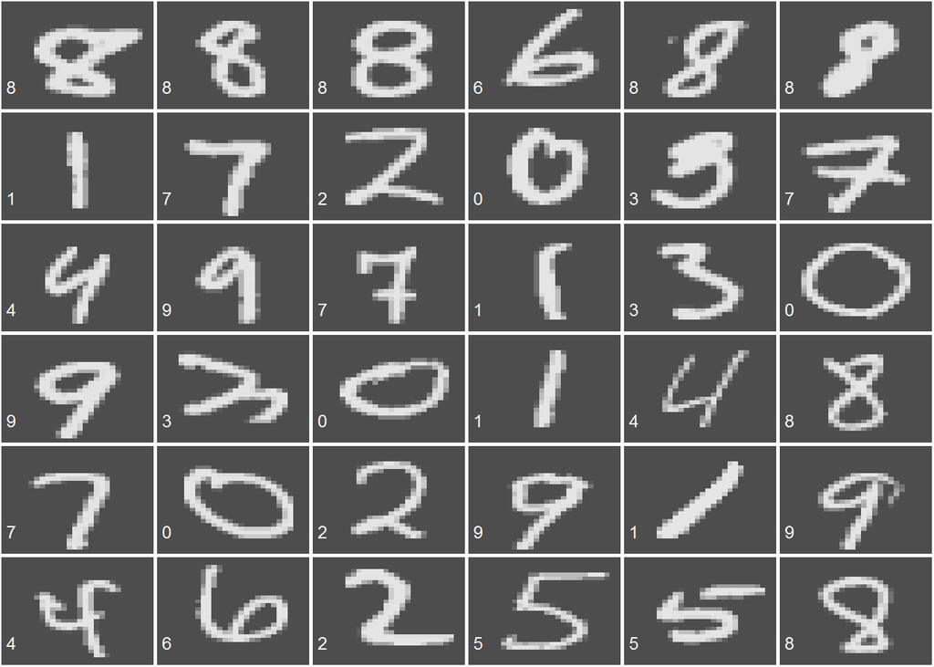

```r
plotTrain <- function(images){
  op <- par(no.readonly=TRUE)
  x <- ceiling(sqrt(length(images)))
  par(mfrow=c(x, x), mar=c(.1, .1, .1, .1))

  for (i in images){ #reverse and transpose each matrix to rotate images
    m <- matrix(dtrain[i,-1], nrow=28, byrow=TRUE)
    m <- apply(m, 2, rev)
    image(t(m), col=grey.colors(255), axes=FALSE)
    text(0.05, 0.2, col="white", cex=1.2, dtrain[i, 1])
  }
  par(op)
}

plotTrain(1:36)
```

# Сверточная нейронная сеть

Сначала каждое изображение должно быть предсталено в виде 3-мерного массива.

```r
dtrain.x <- dtrain[,-1]
dtrain.y <- dtrain[,1]
dtrain.x <- t(dtrain.x/255)

dtrain.array <- dtrain.x
dim(dtrain.array) <- c(28, 28, 1, ncol(dtrain.x))

dtest.x <- dtest[,-1]
dtest.y <- dtest[,1]
dtest.x <- t(dtest.x/255)

dtest.array <- dtest.x
dim(dtest.array) <- c(28, 28, 1, ncol(dtest.x))
```

Строим архитектуру нейронной сети с помощью символов. Вводим символьную переменную, над которой будут проводиться манипуляции:

```r
m1.data <- mx.symbol.Variable("data")
```

Опрделяем сверточный слой.

Некоторые параметры:

kernel – размер ядра (h, w).

stride – величина сдвига окна (h, w).

dilate – расстояние между пикселями в окне (h, w).

pad – размер “подушки из нулей” вокруг входного слоя (h, w).

num.filter – количество сверток.

no.bias – исключение свободного члена.

```r
m1.conv1 <- mx.symbol.Convolution(m1.data, kernel=c(5,5), num_filter=16)
```

Батч-нормализация.

momentum – параметр скользящего среднего, при котором пересчитываются средние. default=0.9

```r
m1.bn1 <- mx.symbol.BatchNorm(m1.conv1)
```

Активация нейронов.

act.type – ‘relu’, ‘sigmoid’, ‘softrelu’, ‘tanh’.

```r
m1.act1 <- mx.symbol.Activation(m1.bn1, act_type="relu")
```

Пулинг (subsampling).

Параметры:

kernel, stride, pad – как в Convolution.

pool.type – ‘avg’, ‘max’, ‘sum’.

```r
m1.pool1 <- mx.symbol.Pooling(m1.act1, pool_type="max", kernel=c(2,2), stride=c(2,2))
```

Дропаут. Узел слоя будет обнулен с вероятностью $p$ на время эпохи.

```r
m1.drop1 <- mx.symbol.Dropout(m1.pool1, p=0.5)
```

Добавляем еще несколько слоев.

```r
m1.conv2 <- mx.symbol.Convolution(m1.drop1, kernel=c(3,3), num_filter=32)
m1.bn2 <- mx.symbol.BatchNorm(m1.conv2)
m1.act2 <- mx.symbol.Activation(m1.bn2, act_type="relu")
m1.pool2 <- mx.symbol.Pooling(m1.act2, pool_type="max", kernel=c(2,2), stride=c(2,2))
m1.drop2 <- mx.symbol.Dropout(m1.pool2, p=0.5)
```

Вытягивание изображения в вектор для подачи на вход полновсязным слоям.

```r
m1.flatten <- mx.symbol.Flatten(m1.drop2)
```

Параметры полносвязного слоя:

num.hidden – количество нейронов на слое.

no.bias – исключение свободного члена.

```r
m1.fc1 <- mx.symbol.FullyConnected(m1.flatten, num_hidden=256)
m1.act3 <- mx.symbol.Activation(m1.fc1, act_type="relu")
```

Выходной слой.

```r
m1.fc2 <- mx.symbol.FullyConnected(m1.act3, num_hidden=10)
```

Применение softmax функции к выходу предыдущего слоя. В этом случае минимизируется кросс-энтропия: $E=-\sum_j y_j\log o_j$, где $y_j$ – правильный ответ, а $o_j$ – вероятности, полученные на выходе softmax функции. В нашем случае при при одном $j=j_0$ $y_j=1$ , а при остальных $j \neq j_0$ $y_j=0$.

```r
m1.softmax <- mx.symbol.SoftmaxOutput(m1.fc2)
```

Визуализация архитектуры нейронной сети.

```r
graph.viz(m1.softmax)
```

[interactive chart not shown]

Обучаем модель. Параметры mx.model.FeedForward.create:

learning.rate – $\eta$,

momentum – $\alpha$,

wd – weight decay $\lambda$.

Изменение вектора весов:

$$\Delta w_i(t+1)=-\eta \frac{\partial Q}{\partial w_i} + \alpha \Delta w_i(t) - \lambda \eta w_i,$$
где $Q$ – функция потерь, $t$ – номер шага. По умолчанию используется SGD.

Справка в R по пакету довольно скудная, более подробное описание этой функции можно найти здесь: https://mxnet.incubator.apache.org/api/python/optimization.html, несмотря на то, что это API для Python, это сильно проясняет как работает функция.

```r
log <- mx.metric.logger$new()
tick <- proc.time()
mx.set.seed(0)

m1 <- mx.model.FeedForward.create(m1.softmax,
                                  X = dtrain.array,
                                  y = dtrain.y,
                                  num.round = 20,
                                  array.batch.size = 100,
                                  array.layout="colmajor",
                                  learning.rate = 0.05,
                                  momentum = 0.91,
                                  wd = 0.00001,
                                  eval.data=list(data=dtest.array, label=dtest.y),
                                  eval.metric = mx.metric.accuracy,
                                  initializer = mx.init.uniform(0.07),
                                  epoch.end.callback = mx.callback.log.train.metric(1, log)
)
```

```
## Start training with 1 devices
```

```
## [1] Train-accuracy=0.686938775510204
```

```
## [1] Validation-accuracy=0.8984
```

```
## [2] Train-accuracy=0.8824
```

```
## [2] Validation-accuracy=0.9206
```

```
## [3] Train-accuracy=0.9214
```

```
## [3] Validation-accuracy=0.952200000000001
```

```
## [4] Train-accuracy=0.9282
```

```
## [4] Validation-accuracy=0.9548
```

```
## [5] Train-accuracy=0.935
```

```
## [5] Validation-accuracy=0.966
```

```
## [6] Train-accuracy=0.9452
```

```
## [6] Validation-accuracy=0.9698
```

```
## [7] Train-accuracy=0.9514
```

```
## [7] Validation-accuracy=0.9732
```

```
## [8] Train-accuracy=0.957800000000001
```

```
## [8] Validation-accuracy=0.9728
```

```
## [9] Train-accuracy=0.9602
```

```
## [9] Validation-accuracy=0.9722
```

```
## [10] Train-accuracy=0.9666
```

```
## [10] Validation-accuracy=0.9722
```

```
## [11] Train-accuracy=0.9586
```

```
## [11] Validation-accuracy=0.975
```

```
## [12] Train-accuracy=0.9656
```

```
## [12] Validation-accuracy=0.978599999999999
```

```
## [13] Train-accuracy=0.9664
```

```
## [13] Validation-accuracy=0.9784
```

```
## [14] Train-accuracy=0.9668
```

```
## [14] Validation-accuracy=0.9736
```

```
## [15] Train-accuracy=0.9746
```

```
## [15] Validation-accuracy=0.9784
```

```
## [16] Train-accuracy=0.9724
```

```
## [16] Validation-accuracy=0.9782
```

```
## [17] Train-accuracy=0.9756
```

```
## [17] Validation-accuracy=0.9786
```

```
## [18] Train-accuracy=0.9748
```

```
## [18] Validation-accuracy=0.9774
```

```
## [19] Train-accuracy=0.9756
```

```
## [19] Validation-accuracy=0.9728
```

```
## [20] Train-accuracy=0.9776
```

```
## [20] Validation-accuracy=0.9808
```

```r
print(paste("Training took:", round((proc.time() - tick)[3],2),"seconds"))
```

```
## [1] "Training took: 383.39 seconds"
```

# Сравнение с полносвязной архитектурой.

Поскольку обучение, выбор архитектуры и гиперпараметров трудоемки, я приведу в качестве примеров попытки других людей использовать различные архитектуры. Все примеры с тем же датасетом – MNIST.

## Полносвязная архитектура

Взято отсюда: https://mxnet.incubator.apache.org/tutorials/python/mnist.html Заявленная точность на тестовой выборке 96%.

```r
# input
data <- mx.symbol.Variable('data')

# The first fully-connected layer and the corresponding activation function
fc1  = mx.symbol.FullyConnected(data, num_hidden=128)
act1 = mx.symbol.Activation(fc1, act_type="relu")

# The second fully-connected layer and the corresponding activation function
fc2  = mx.symbol.FullyConnected(act1, num_hidden = 64)
act2 = mx.symbol.Activation(fc2, act_type="relu")

# MNIST has 10 classes
fc3  = mx.symbol.FullyConnected(act2, num_hidden=10)
# Softmax with cross entropy loss
mlp  = mx.symbol.SoftmaxOutput(fc3)
```

```r
graph.viz(mlp)
```

[interactive chart not shown]

## Сверточная нейронная сеть

Взято отсюда: https://www.kaggle.com/srlmayor/easy-neural-network-in-r-for-0-994 Заявленная точность на тестовой выборке 99.414%.

```r
m2.data <- mx.symbol.Variable("data")

# 1st convolutional layer
m2.conv1 <- mx.symbol.Convolution(m2.data, kernel=c(5,5), num_filter=16)
m2.bn1 <- mx.symbol.BatchNorm(m2.conv1)
m2.act1 <- mx.symbol.Activation(m2.bn1, act_type="relu")
m2.pool1 <- mx.symbol.Pooling(m2.act1, pool_type="max", kernel=c(2,2), stride=c(2,2))
m2.drop1 <- mx.symbol.Dropout(m2.pool1, p=0.5)

# 2nd convolutional layer
m2.conv2 <- mx.symbol.Convolution(m2.drop1, kernel=c(3,3), num_filter=32)
m2.bn2 <- mx.symbol.BatchNorm(m2.conv2)
m2.act2 <- mx.symbol.Activation(m2.bn2, act_type="relu")
m2.pool2 <- mx.symbol.Pooling(m2.act2, pool_type="max", kernel=c(2,2), stride=c(2,2))
m2.drop2 <- mx.symbol.Dropout(m2.pool2, p=0.5)
m2.flatten <- mx.symbol.Flatten(m2.drop2)

# 4 Fully Connected layers
m2.fc1 <- mx.symbol.FullyConnected(m2.flatten, num_hidden=1024)
m2.act3 <- mx.symbol.Activation(m2.fc1, act_type="relu")

m2.fc2 <- mx.symbol.FullyConnected(m2.act3, num_hidden=512)
m2.act4 <- mx.symbol.Activation(m2.fc2, act_type="relu")

m2.fc3 <- mx.symbol.FullyConnected(m2.act4, num_hidden=256)
m2.act5 <- mx.symbol.Activation(m2.fc3, act_type="relu")

m2.fc4 <- mx.symbol.FullyConnected(m2.act5, num_hidden=10)
m2.softmax <- mx.symbol.SoftmaxOutput(m2.fc4)
```

```r
graph.viz(m2.softmax)
```

[interactive chart not shown]

# Построение графа для ResNet

```r
m3.data <- mx.symbol.Variable("data")

# 1st convolutional layer
m3.conv1 <- mx.symbol.Convolution(m3.data, kernel=c(5,5), num_filter=16)
m3.act1 <- mx.symbol.Activation(m3.conv1, act_type="relu")

# 2nd convolutional layer
m3.conv2 <- mx.symbol.Convolution(m3.act1, pad=c(3,3), kernel=c(5,5), num_filter=16)

# Sum with previous layer
m3.sum1 <- m3.act1+m3.conv2
m3.act2 <- mx.symbol.Activation(m3.sum1, act_type="relu")

m3.flatten <- mx.symbol.Flatten(m3.act2)

m3.fc1 <- mx.symbol.FullyConnected(m3.flatten, num_hidden=256)
m3.act3 <- mx.symbol.Activation(m3.fc1, act_type="relu")

m3.fc2 <- mx.symbol.FullyConnected(m3.act3, num_hidden=10)
m3.softmax <- mx.symbol.SoftmaxOutput(m3.fc2)
```

```r
graph.viz(m3.softmax)
```

[interactive chart not shown]

# Блок DenseNet

Здесь уже нет необходимости в одинаковой глубине, т.к. мы просто конкатенируем слои, но все еще нужно, чтобы размеры feature map’ов совпадали.

```r
m4.data <- mx.symbol.Variable("data")

# 1st convolutional layer
m4.conv1 <- mx.symbol.Convolution(m4.data, kernel=c(5,5), num_filter=16)
m4.act1 <- mx.symbol.Activation(m4.conv1, act_type="relu")

# 2nd convolutional layer
m4.conv2 <- mx.symbol.Convolution(m4.act1, pad=c(3,3), kernel=c(5,5), num_filter=8)
m4.concat1<-mx.symbol.concat(list(m4.act1,m4.conv2), num.args=2, dim=3)
m4.act2 <- mx.symbol.Activation(m4.concat1, act_type="relu")

# 3rd convolutional layer
m4.conv3 <- mx.symbol.Convolution(m4.act2, pad=c(3,3), kernel=c(5,5), num_filter=4)
m4.concat2<-mx.symbol.concat(list(m4.act1,m4.act2,m4.conv2), num.args=3, dim=3)
m4.act3 <- mx.symbol.Activation(m4.concat2, act_type="relu")

# 4th convolutional layer
m4.conv4 <- mx.symbol.Convolution(m4.act3, pad=c(3,3), kernel=c(5,5), num_filter=4)
m4.concat3<-mx.symbol.concat(list(m4.act1,m4.act2,m4.act3,m4.conv2), num.args=4, dim=3)
m4.act4 <- mx.symbol.Activation(m4.concat3, act_type="relu")
```

```r
graph.viz(m4.act4)
```

[interactive chart not shown]